# Climate Vulnerability Indicators for Salmon: Methods and Results (draft)

### Change in August flow (station model)

This is an alternative indicator for low August flows using a statistically downscaled model of flows at gauge stations in BC (Ruzzante in prep.) It is included for comparison to the PCIC VIC-GL stream model. The projections for this model use the CMIP6 suite of global climate models, unlike the other models which are all based on CMIP5 models.

#### 45

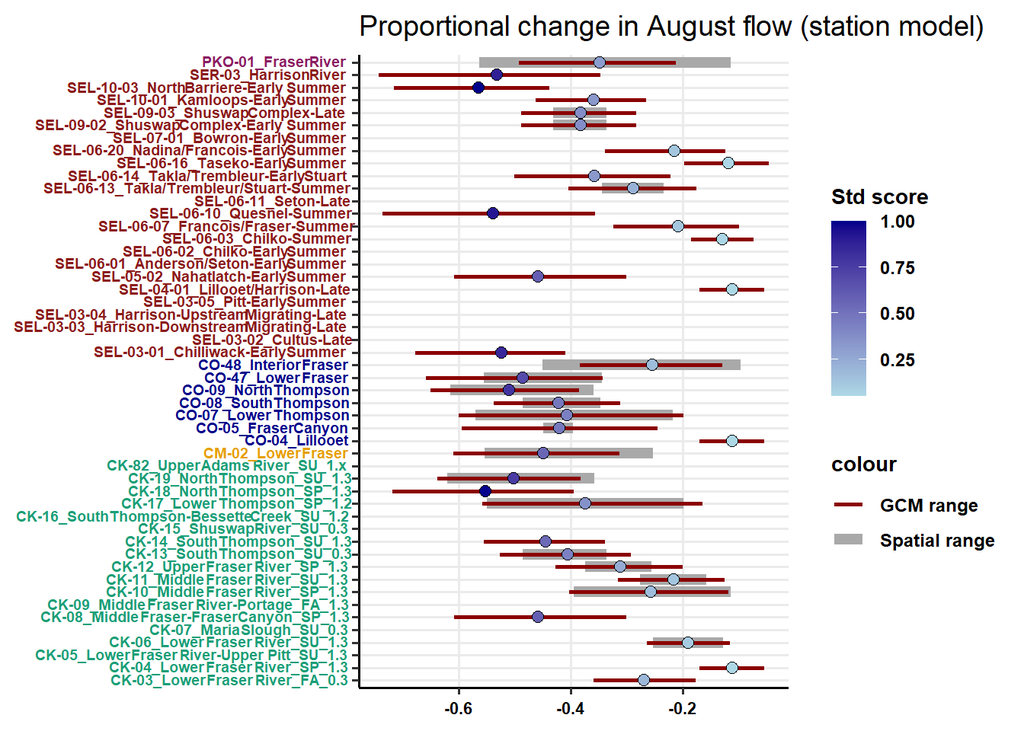

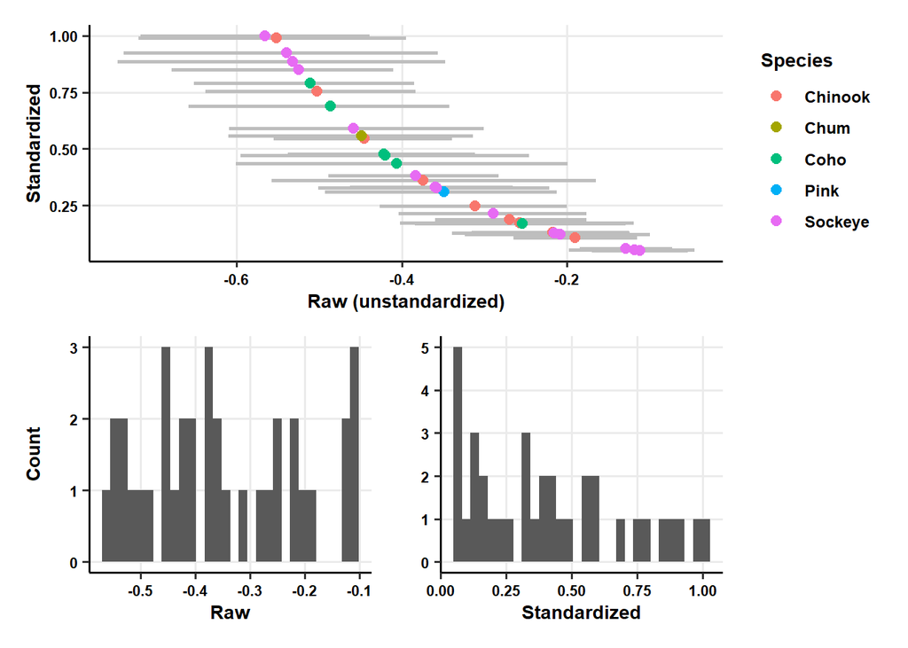

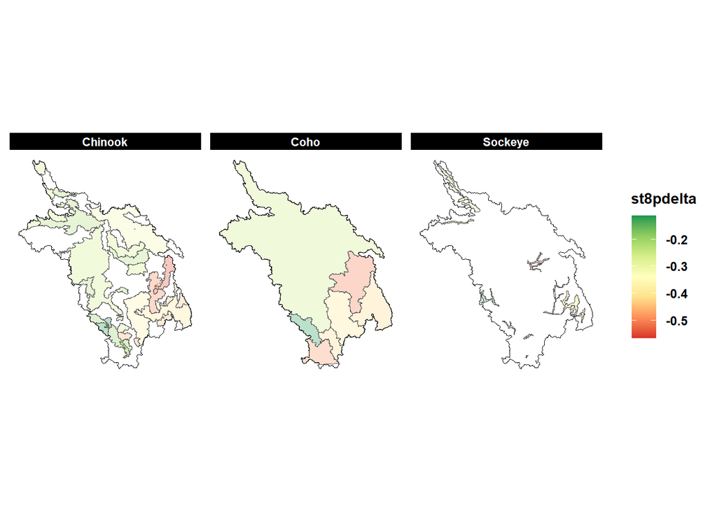

#### 85

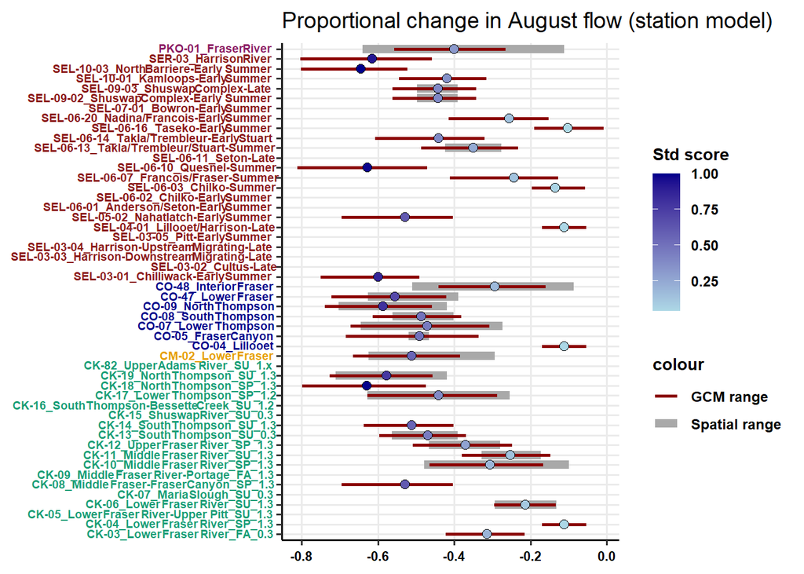

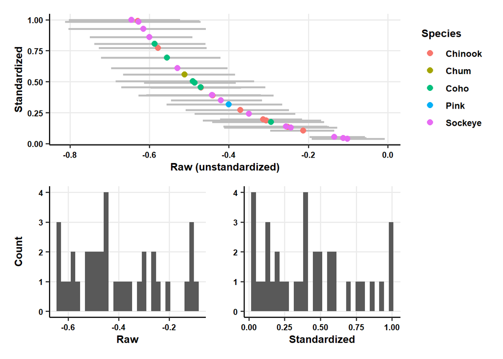

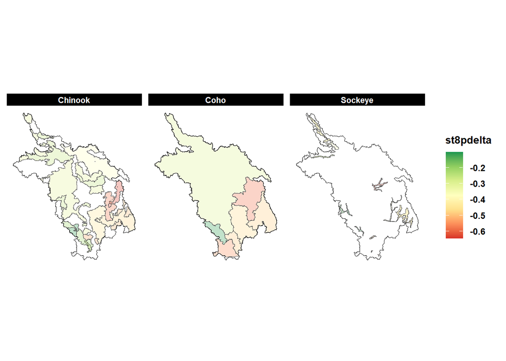

### Change in Nov-Jan flow

The proportional change in flows from November to January were assessed using model projections from the PCIC VIC-GL model downscaled to the stream network within the Fraser basin. Increases in flows during this period may cause redd scour and lead to higher mortality during egg incubation.

#### 45

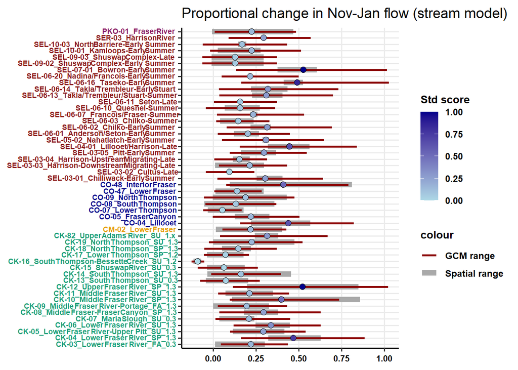

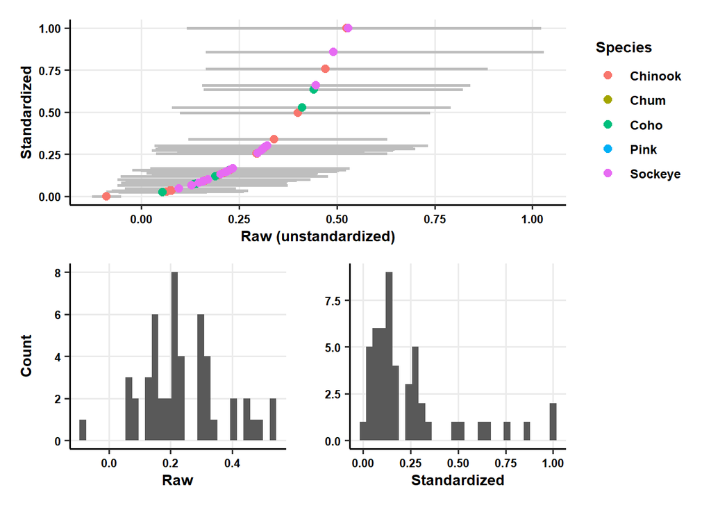

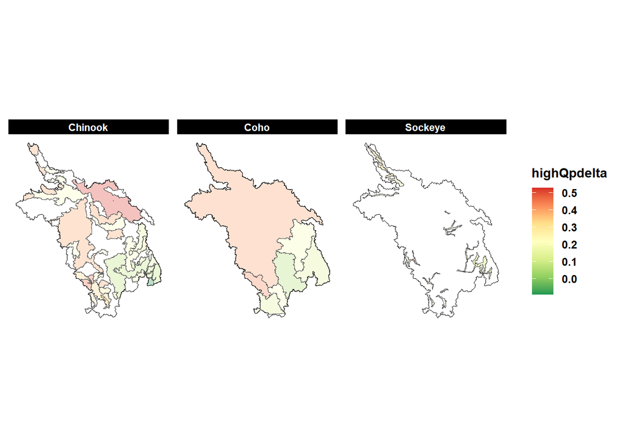

#### 85

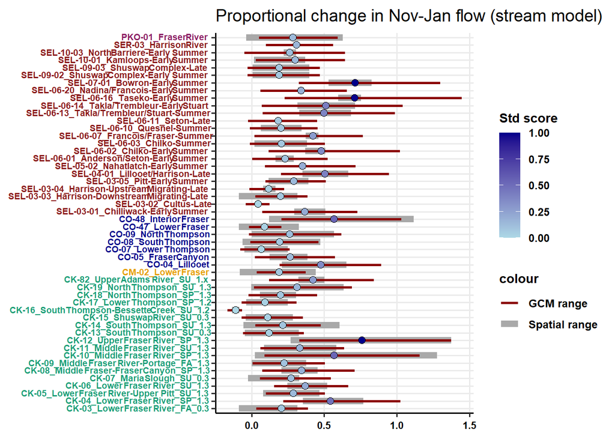

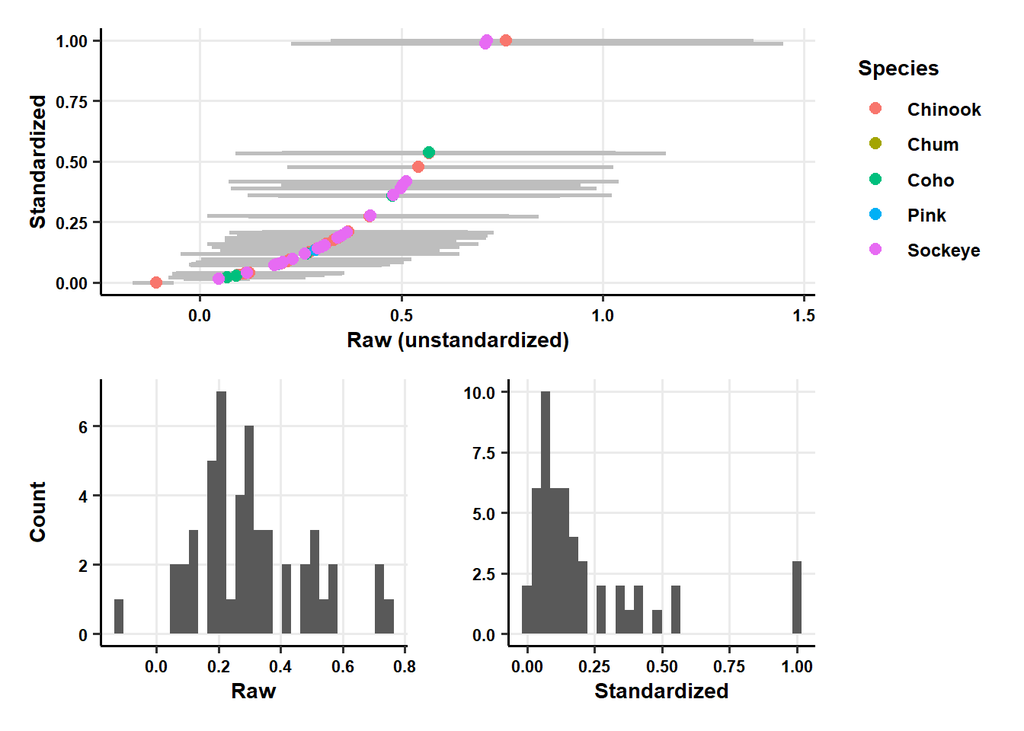

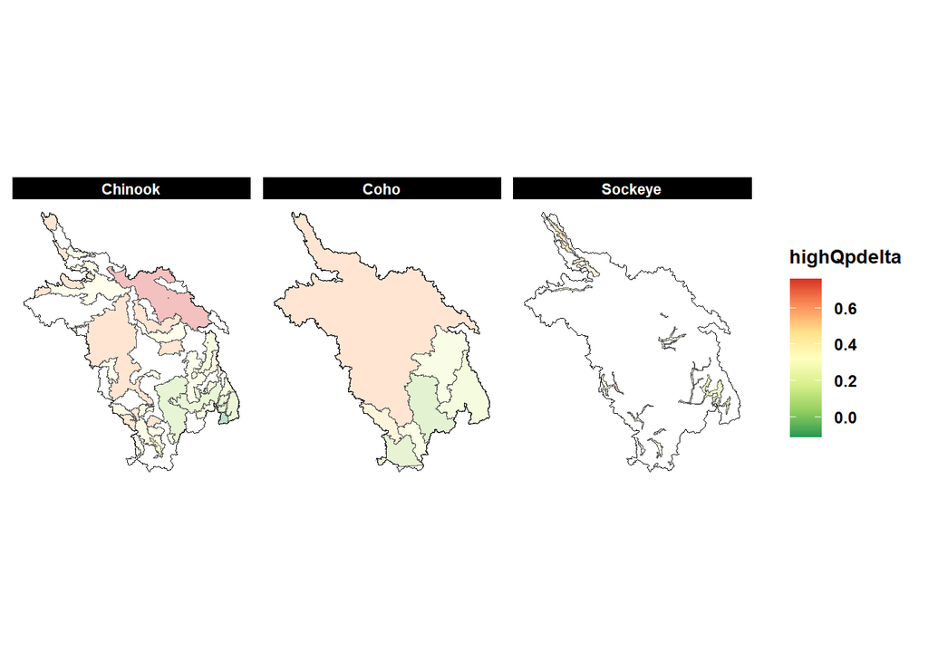

### Cumulative threats

#### 45

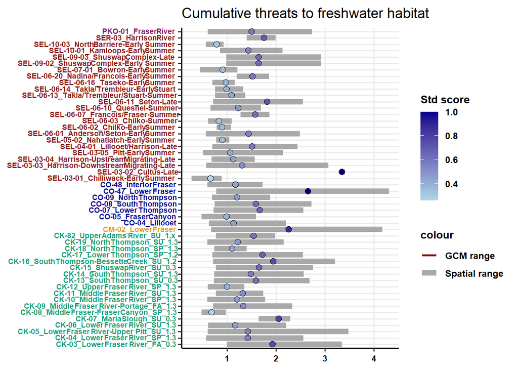

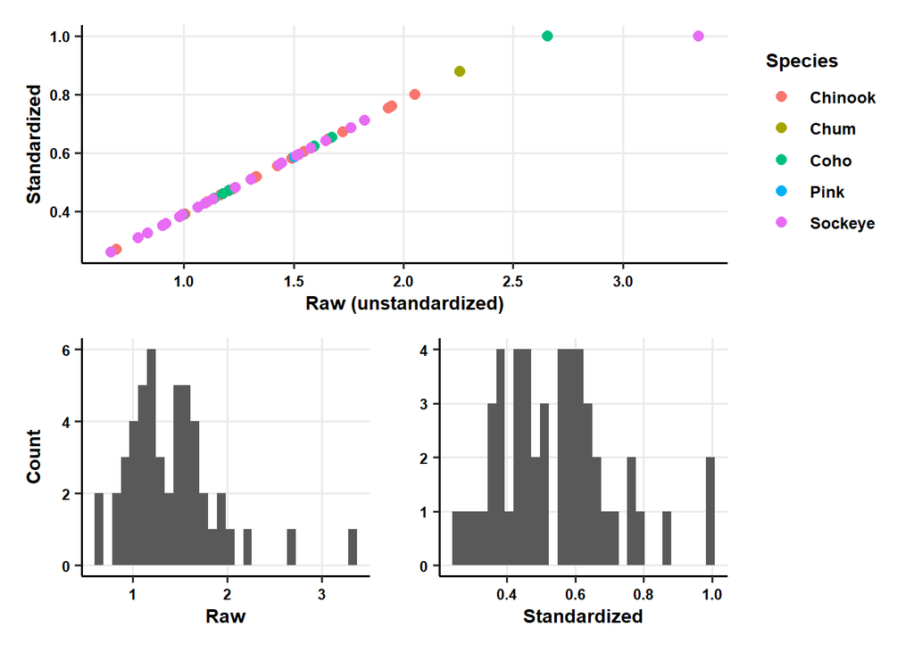

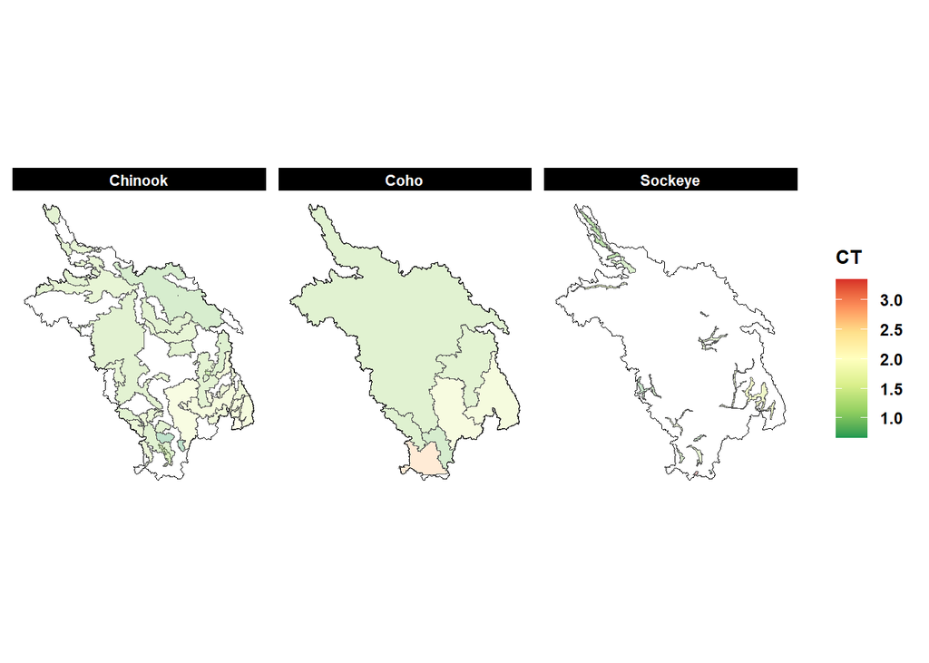

#### 85

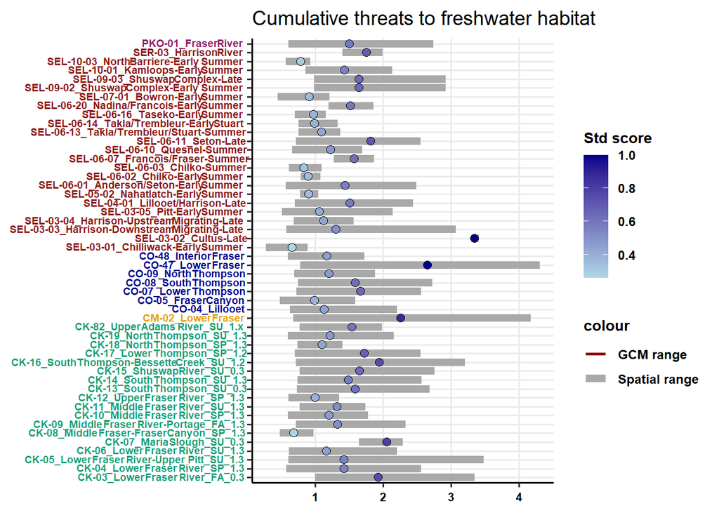

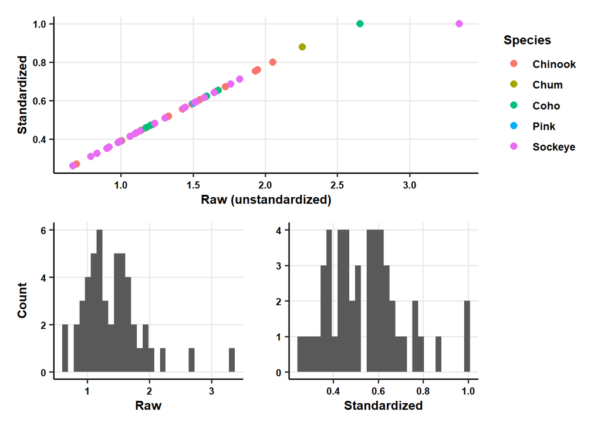

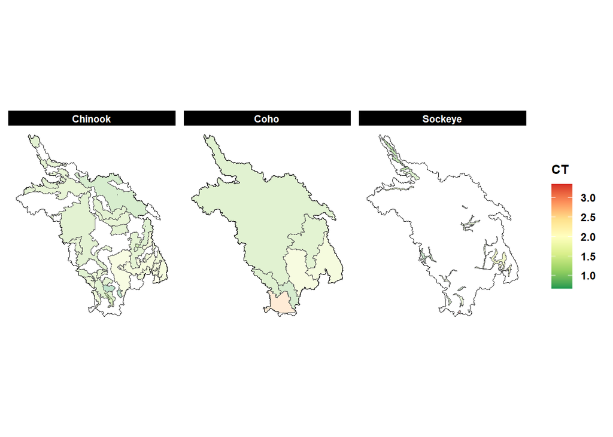

### ENM Favourability Change

#### 45

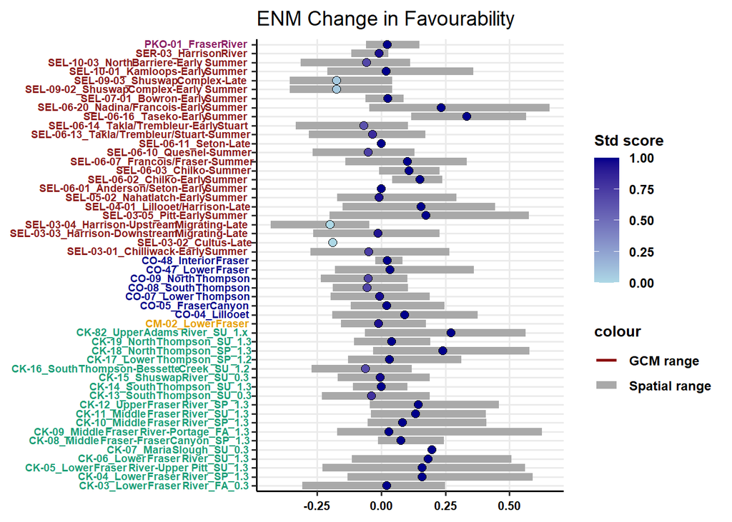

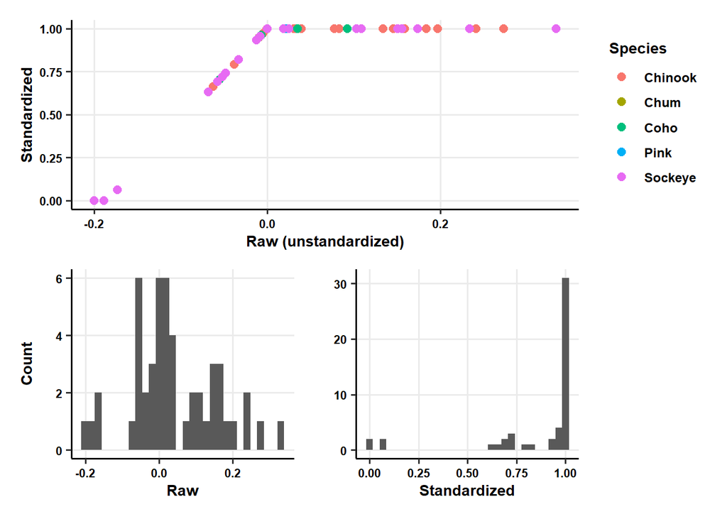

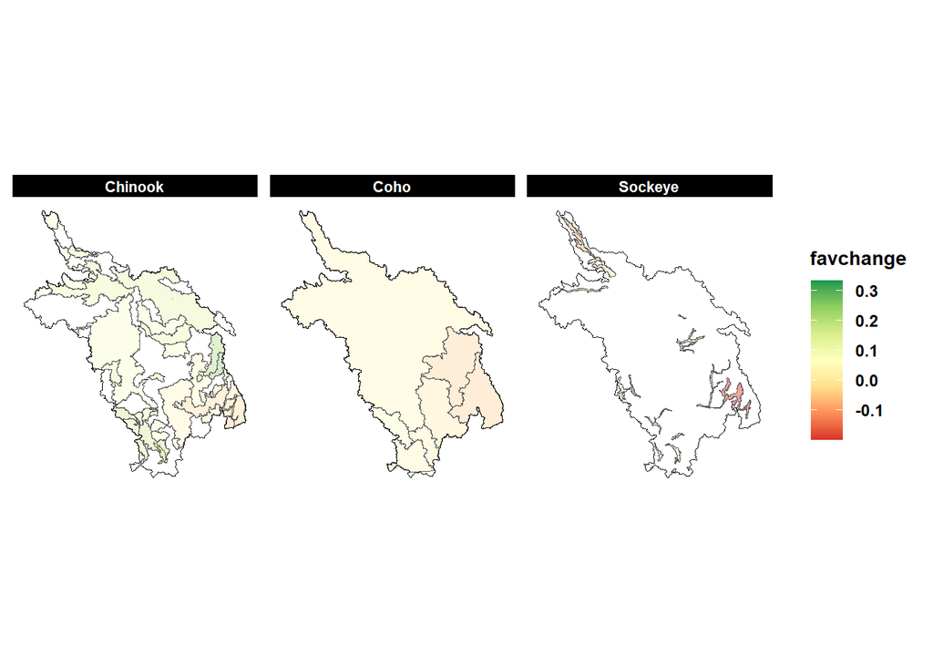

#### 85

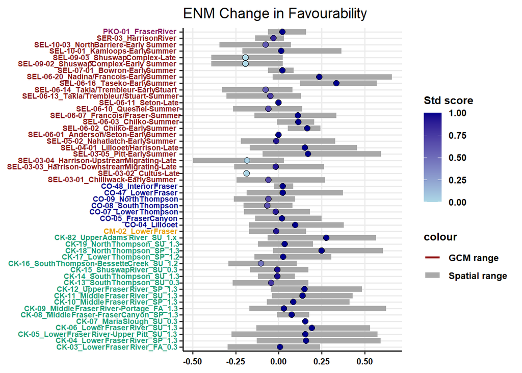

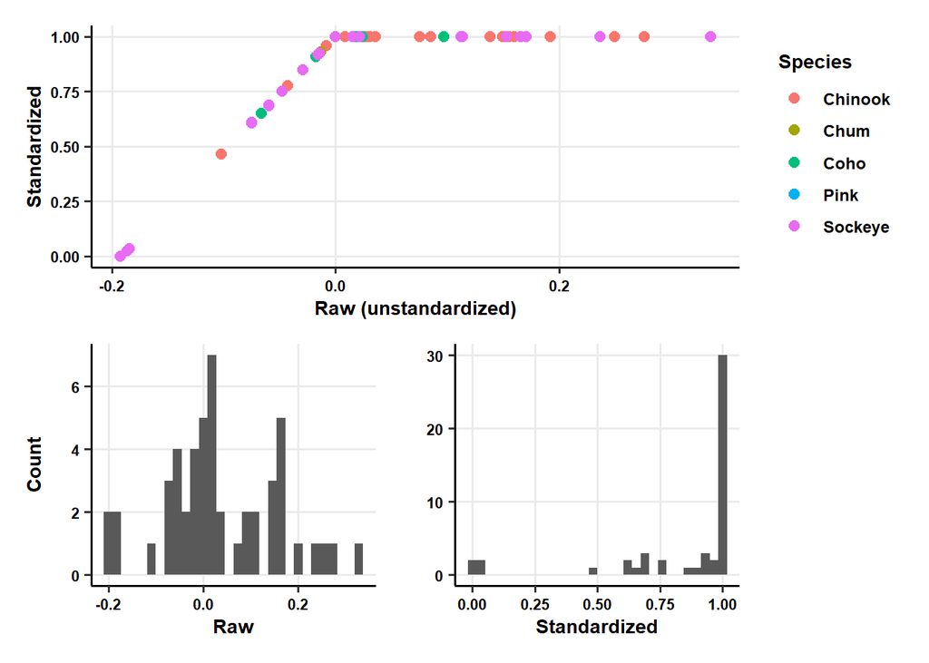

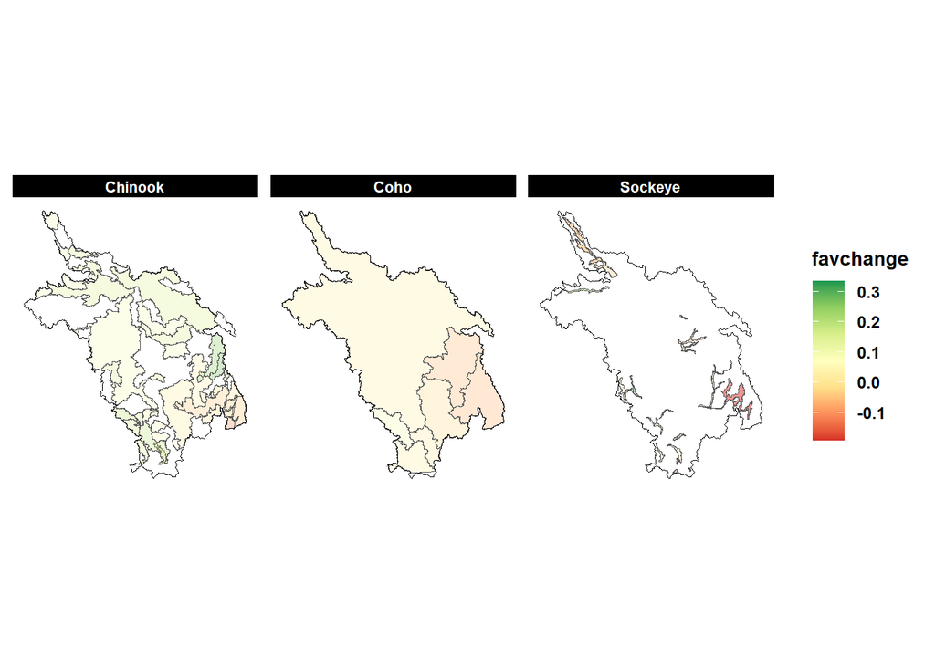

# Upstream Migration

### Data Sources

**PCIC Variable Infiltration Capacity With Glaciers (VIC-GL) gridded model** - Dynamically downscaled projections of stream temperature and flow from 1980 to 2099 for gauged watersheds within British Columbia [https://pacificclimate.org/analysis-tools/salmon-climate-impacts-portal]  
**PSF CU-Specific Life History Timing** - timing of freshwater life history events for each CU [https://datadryad.org/dataset/doi:10.5061/dryad.wm37pvmwx]

**NUSEDS (New Spawning Escapement Database)** - CU spawning sites used to determine migration end points [https://open.canada.ca/data/en/dataset/c48669a3-045b-400d-b730-48aafe8c5ee6]

### Analysis Methods

Indicators for the upstream migration life stage represent changes to stream temperatures and flows, and distance to spawning sites. For each CU, a migration path from river mouth to NUSEDS spawning sites was subsetted from the BC Freshwater Atlas stream network. The upstream migration distance was calculated as the length of all stream segments within the migration path, weighted by the proportion of spawning sites that terminated past the segment.

To estimate temperatures and flow during upstream migration, an upstream movement model was applied to stream segments within the migration path and used to subset days of the year and spatial grid cells from the VIC-GL model. The model began with stream segments within 100km of the river mouth at the start of run timing. The front end of this spatial subset was moved upstream at a rate equal to the distance to spawning sites divided by the number of days between spawn timing start and run timing start. This assumes that the spawn timing start coincides with arrival to the spawning sites. The tail end of the migration was modelled to arrive at the spawning grounds at the peak spawn date, and moved upstream from the river mouth at a rate equal to the distance to spawning sites divided by the number of days between spawn timing peak and run timing end.

Upstream migration indicators

| abbrev | type | stat | std_fun | name |
| --- | --- | --- | --- | --- |
| migrT | migr | mean | exponential_std | Projected temperature during upstream migration |
| migrQ | migr | pdelta | decay_std | Proportional change in discharge during upstream migration |
| migrA21 | migr | mean | exponential_std | Average proportion of path above 21 degrees during upstream migration |
| migrdist | migr | value | linear_std | Length of upstream migration |

### Projected temperature during migration

#### 45

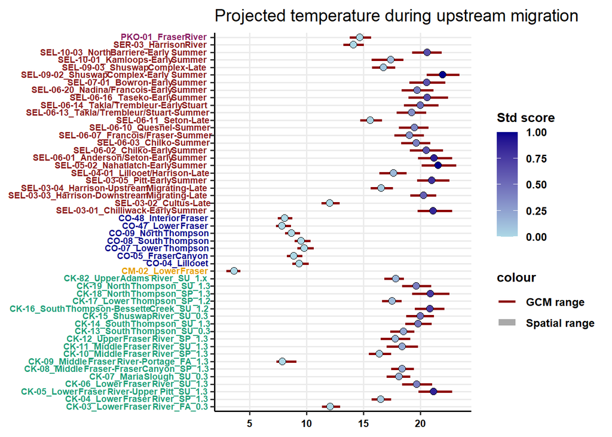

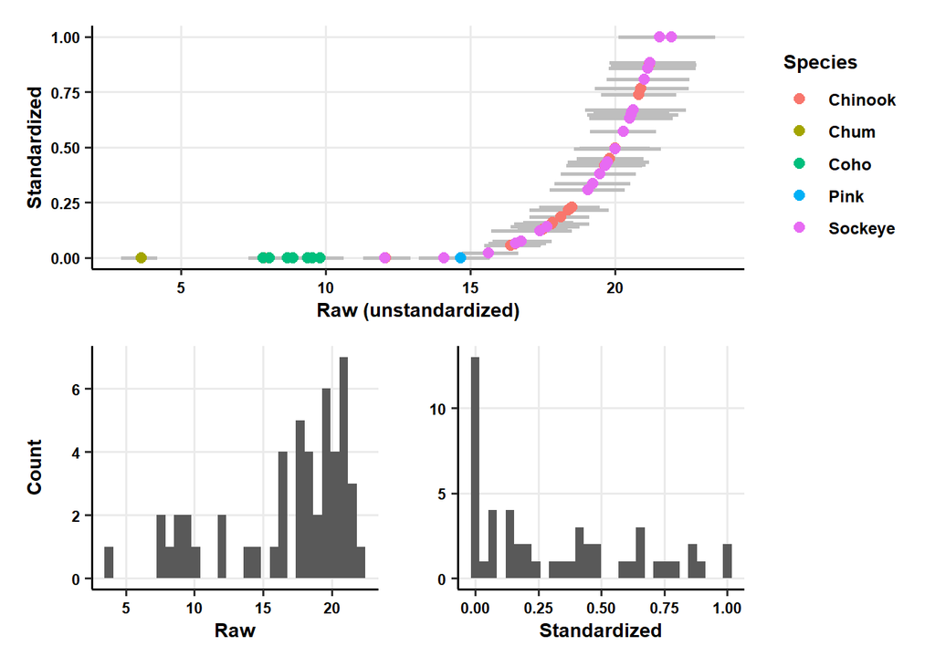

#### 85

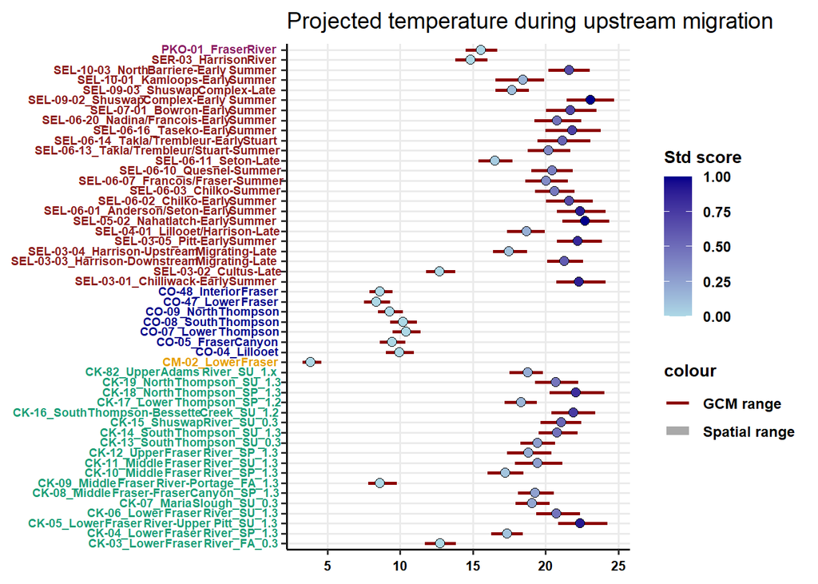

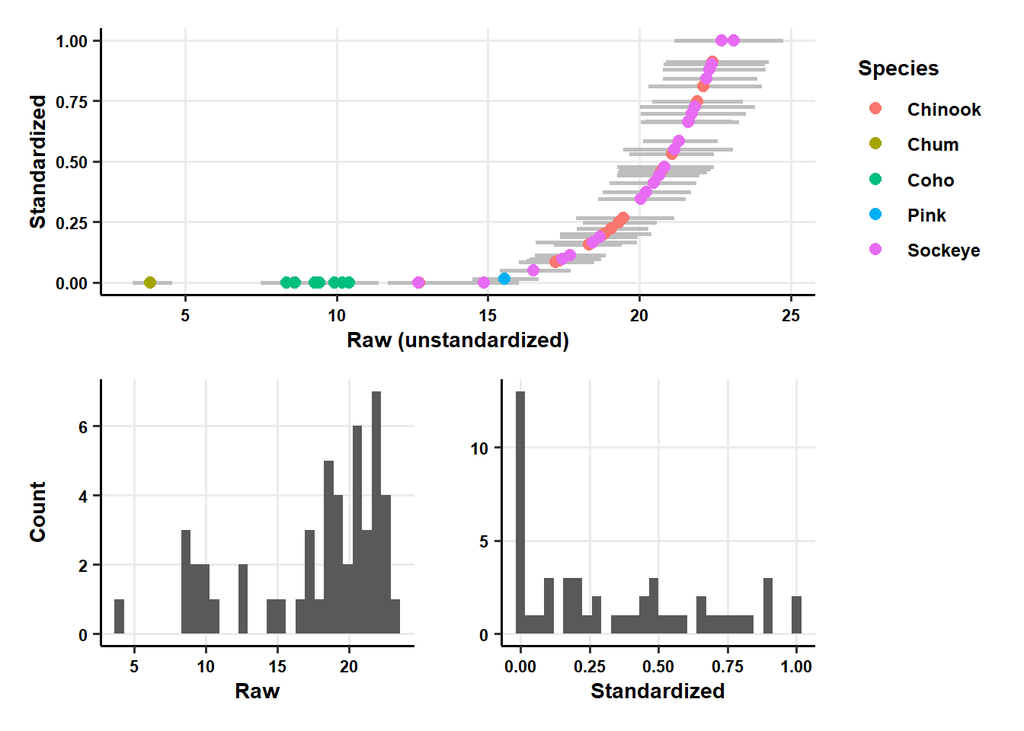

### Projected proportion of migration above 21 degrees C

#### 45

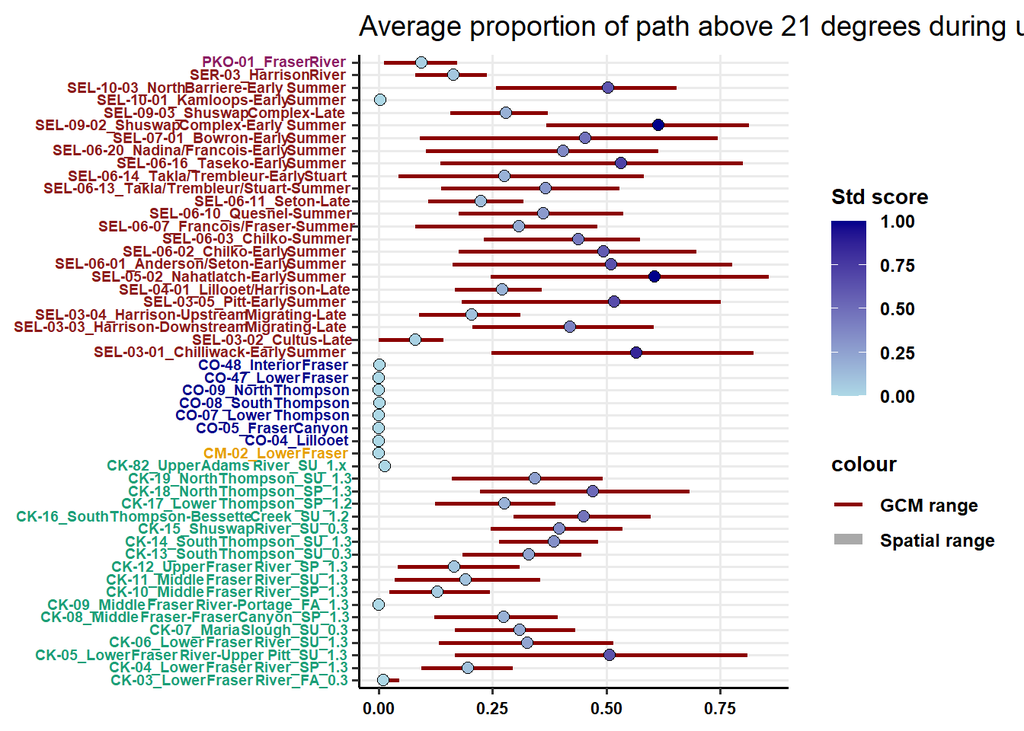

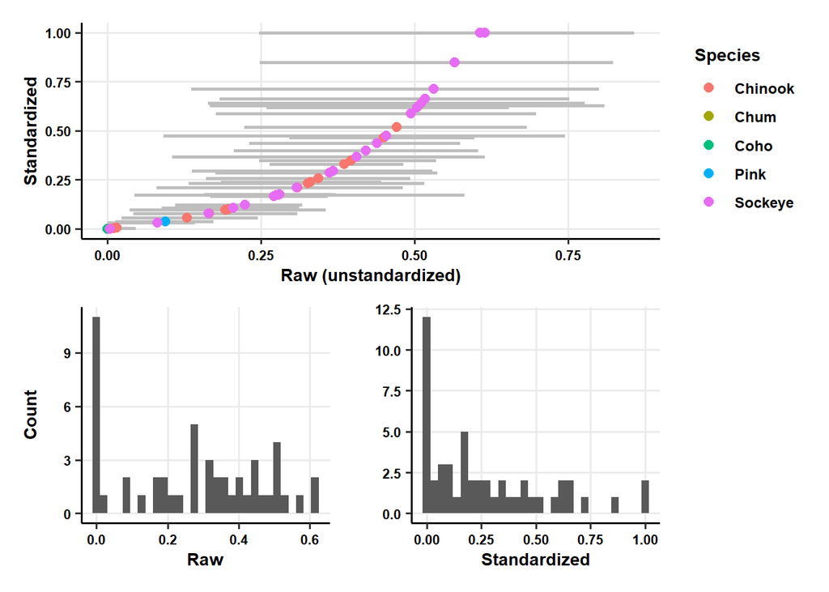

#### 85

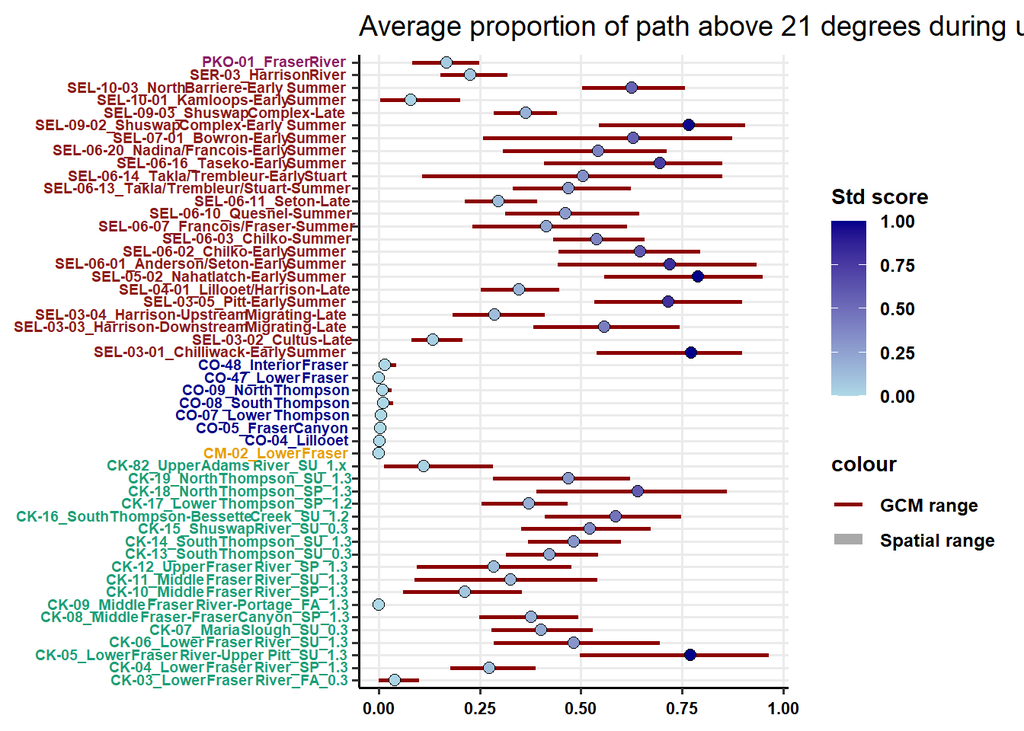

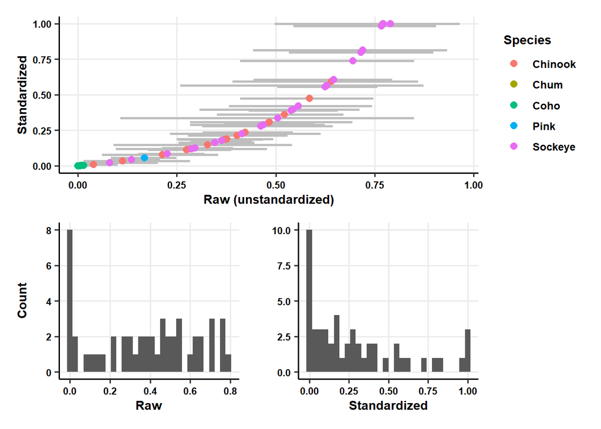

### Change in discharge during migration

#### 45

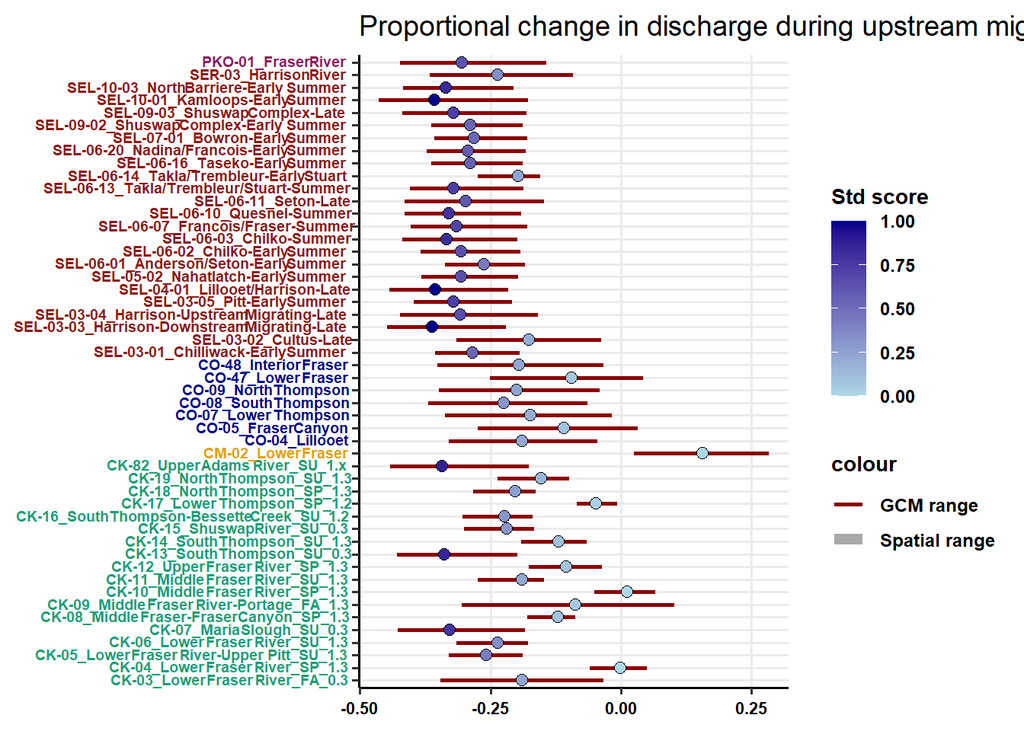

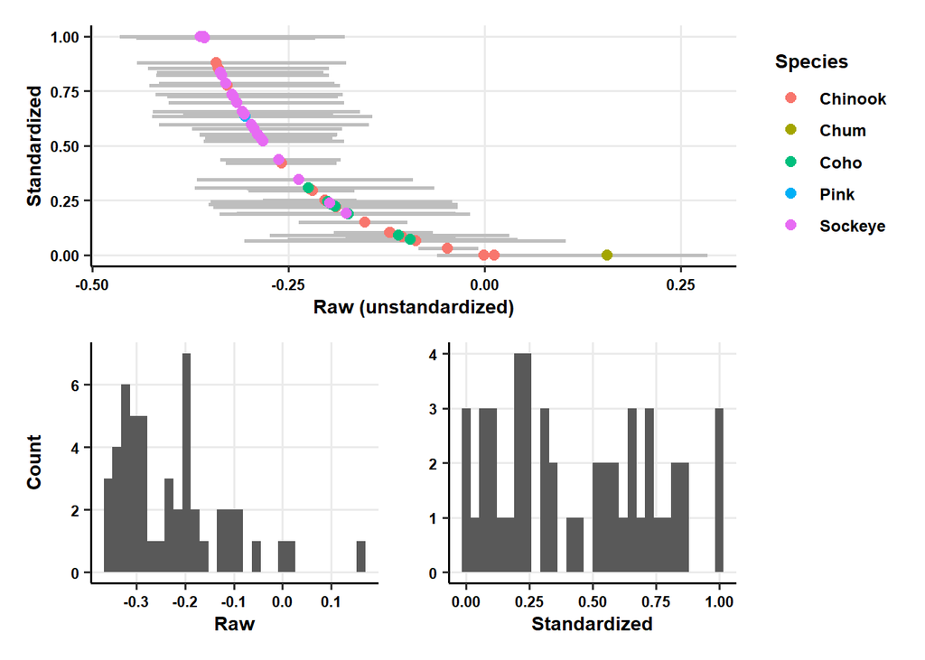

#### 85

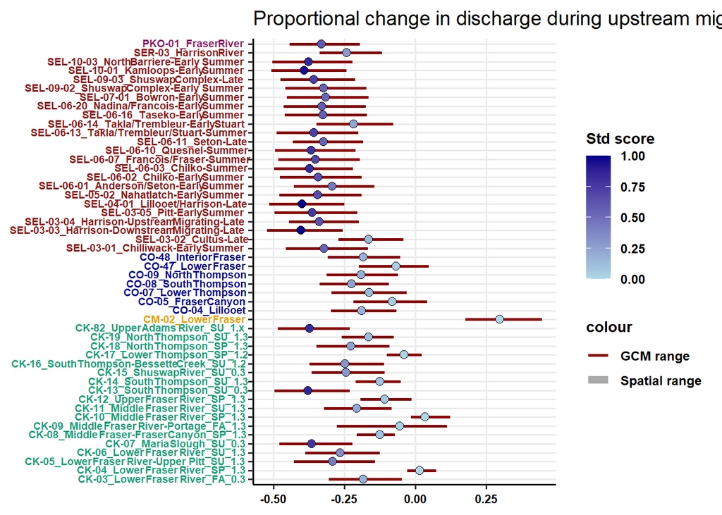

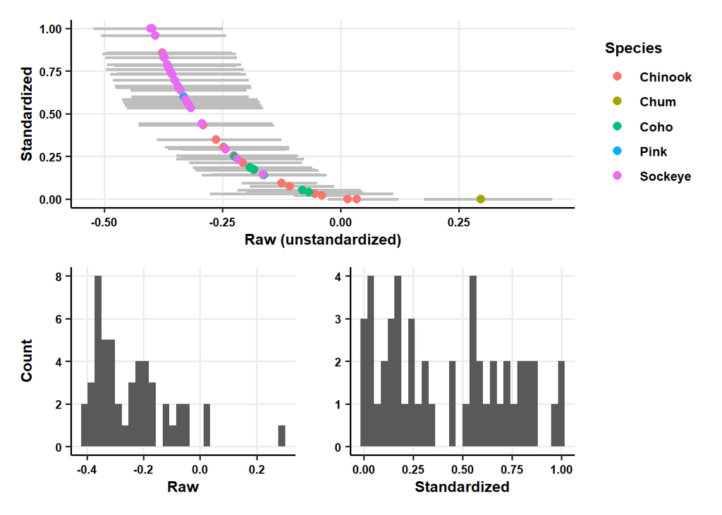

### Length of upstream migration

#### 45

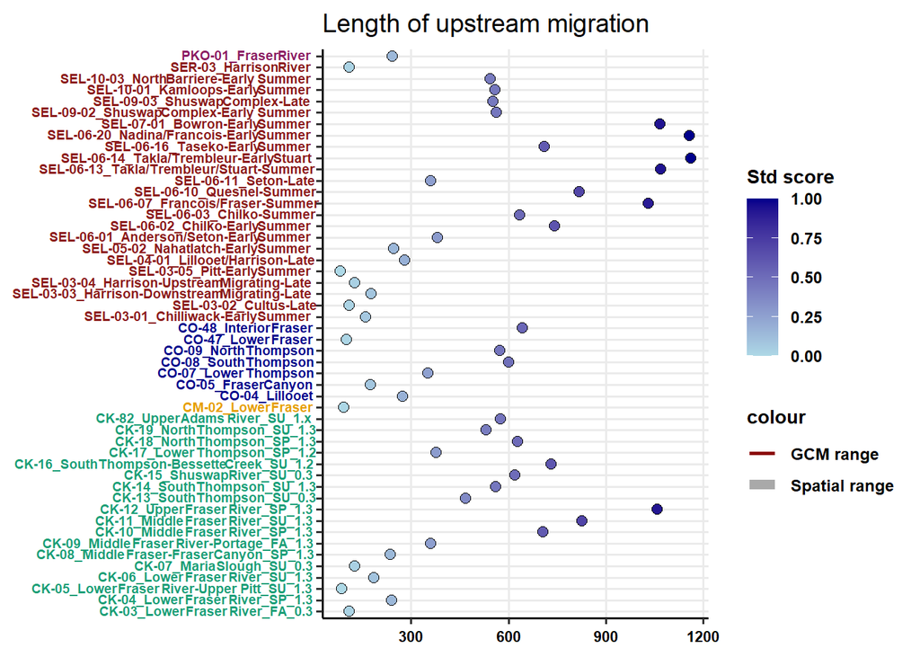

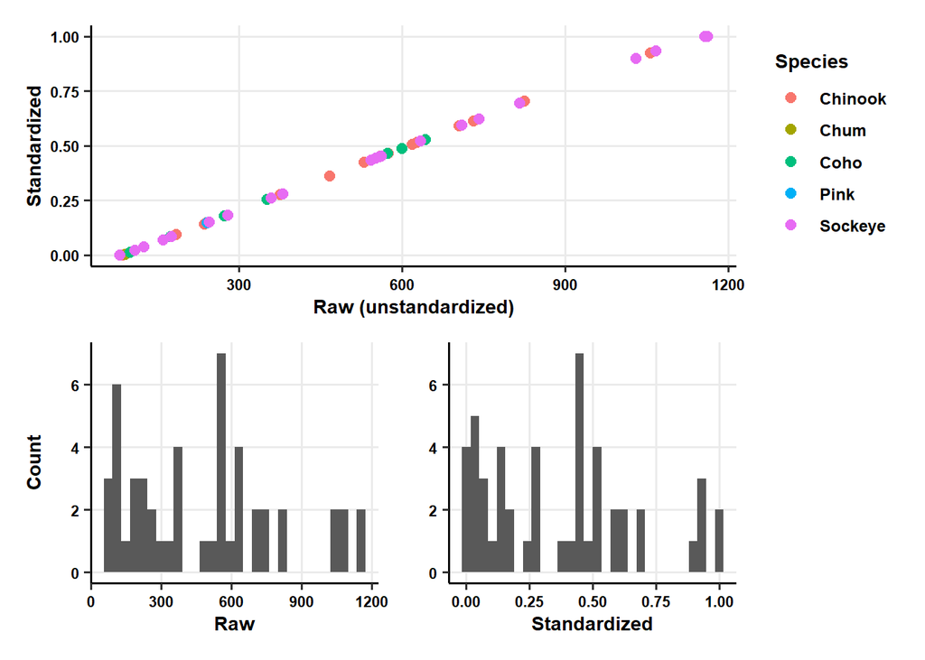

#### 85

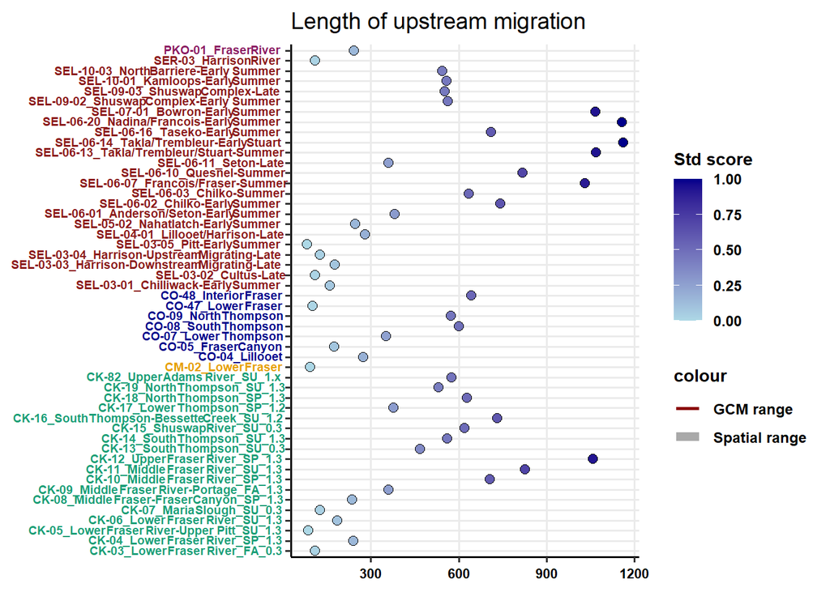

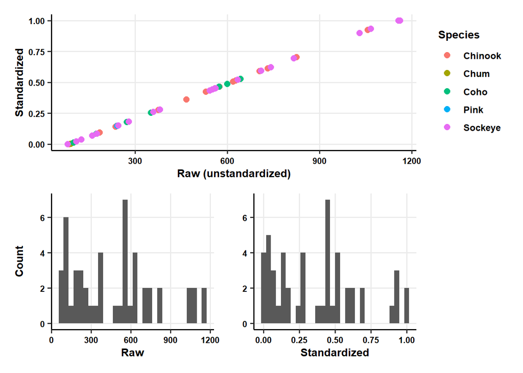

# Demographic indicators

### Data Sources

**WSP Status Assessments** - Recent assessments for Fraser basin conservation units using methods described in CSAS 2024 [https://www.dfo-mpo.gc.ca/csas-sccs/Publications/ScR-RS/2024/2024_004-eng.html]

### Methods

Demographic indicators were derived from recent Wild Salmon Policy assessments in the Fraser Basin using the Rapid Status Approximations method. The status indicator represents the categorical status assessments (Red, Red/Amber, Amber, Amber/Green, Green), which is transformed between 0 to 1 using a step transformation, where 0 represents a Green status and 1 is Red status. The number of mature individuals is calculated as the arithmetic mean of the number of spawners from the most recent generation for which data was compiled and available.

Demographics indicators

| abbrev | type | stat | std_fun | name |
| --- | --- | --- | --- | --- |
| CUstatus | dem | category | cat_std | WSP status |
| CUnmat | dem | value | decay_std | Number of mature individuals |

### WSP Status

#### 45

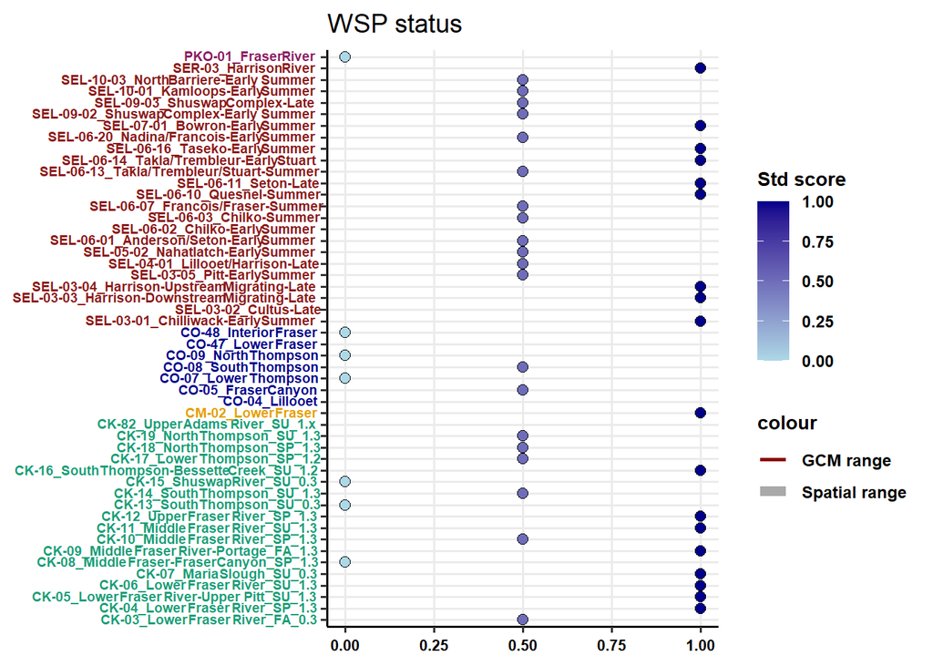

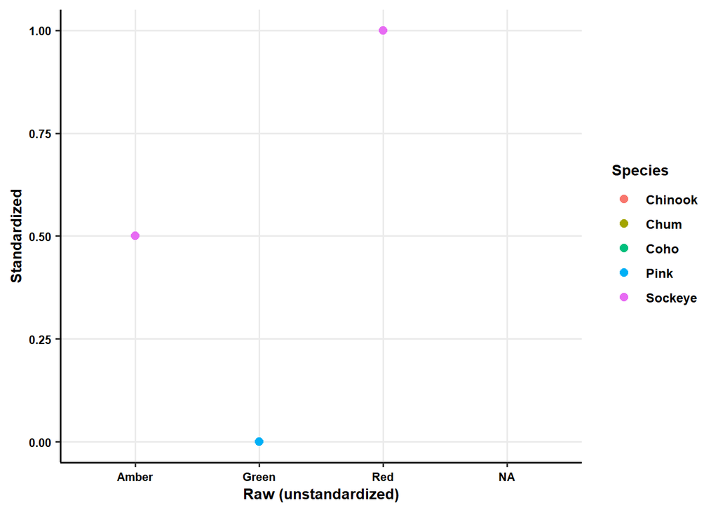

#### 85

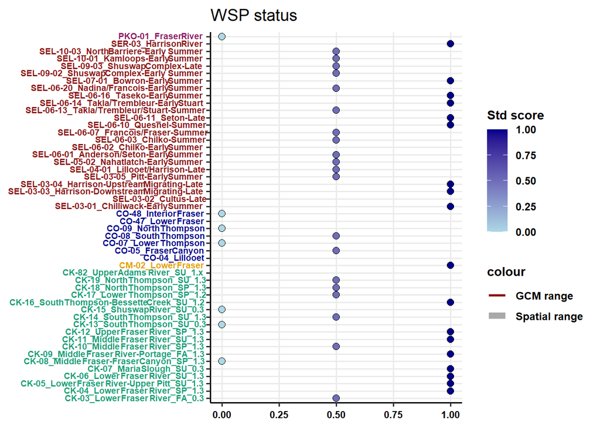

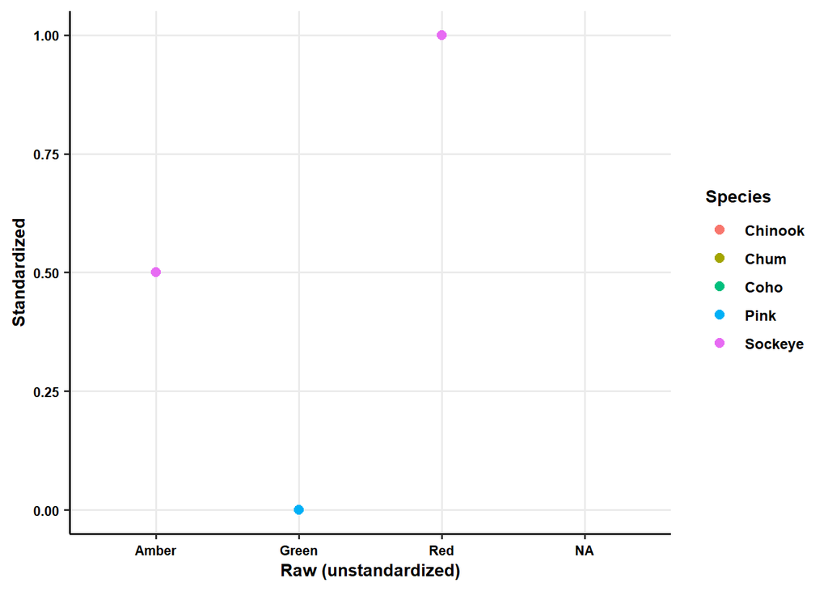

### Number of mature individuals

#### 45

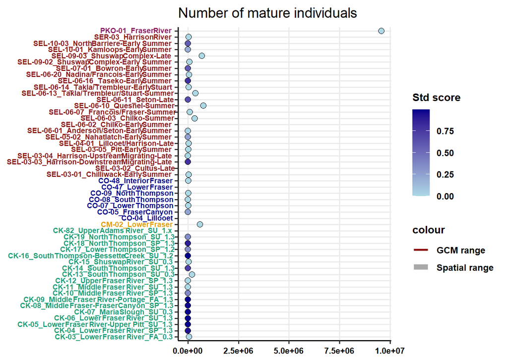

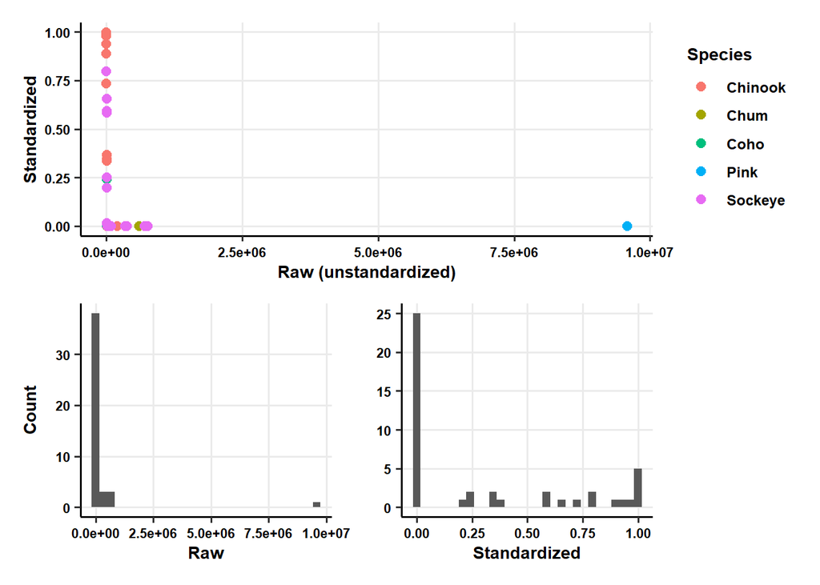

#### 85

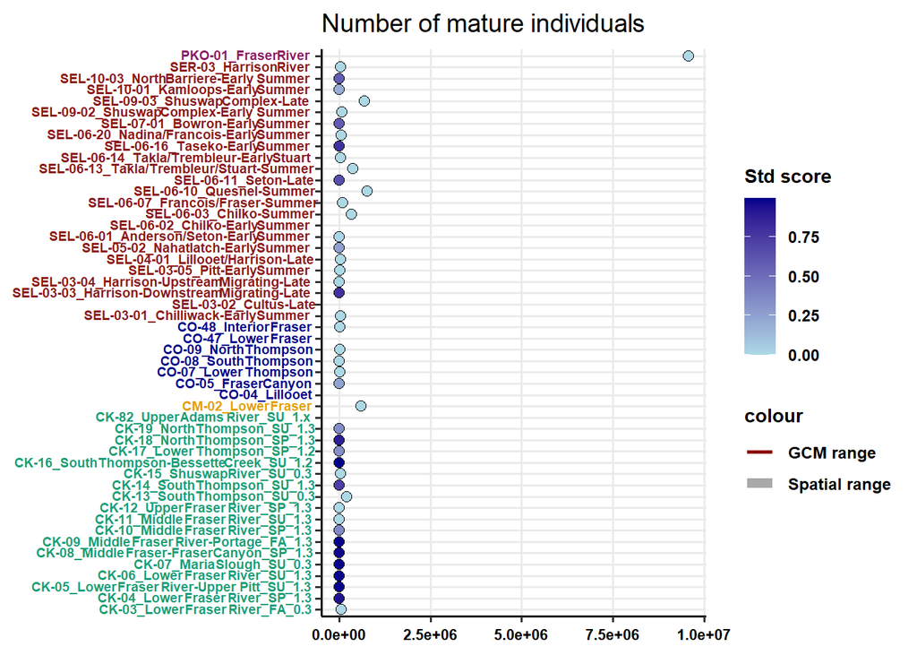

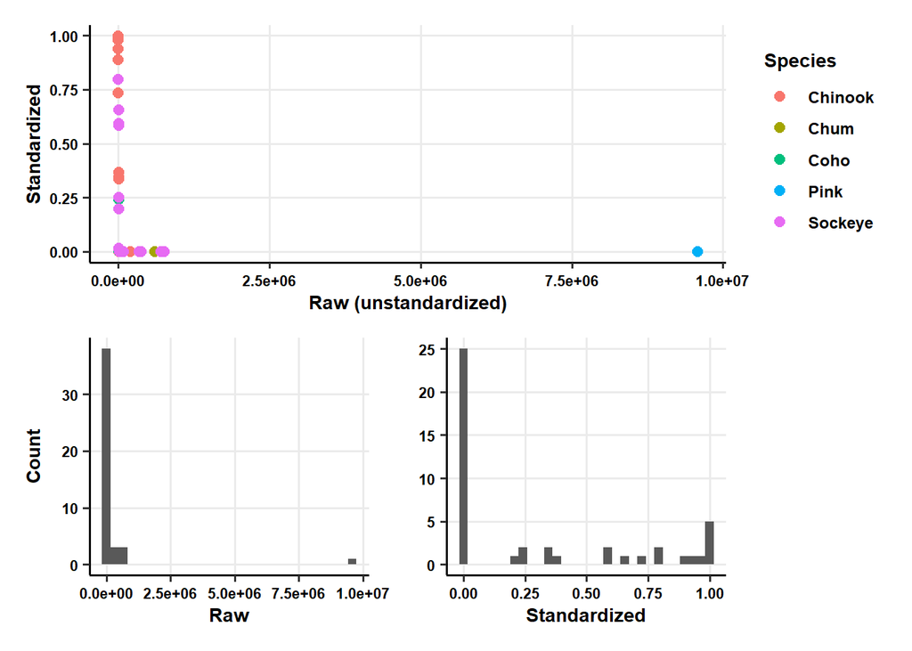

# Nearshore marine indicators

### Data Sources

**PSF CU-Specific Life History Timing** - ocean entry timing used to determine projected SST [https://datadryad.org/dataset/doi:10.5061/dryad.wm37pvmwx]

**HOTSSea -** hindcast of the Salish Sea used for the historical climatology of SST [https://gmd.copernicus.org/articles/18/211/2025/]

**SalishSeaCast** - Regional oceanographic model of the Salish Sea used for projected SST between 2046-2065

**Marine Adaptive Zones** - Developed as part of CU definitions by Holtby and Ciruna (2007), adjusted to cover the marine regions.

**Cumulative Impacts -** Marine habitat cumulative impacts [https://www.dfo-mpo.gc.ca/csas-sccs/Publications/ResDocs-DocRech/2024/2024_024-eng.html]

### Analysis Methods

Marine indicators represent changes to sea surface temperature within marine adaptive zones surrounding the period of marine entry for each conservation unit. Sea surface temperature projections from the Salish Sea Cast model were averaged for the month prior to the start of ocean entry to the month following the end of ocean entry. Historical climatologies were estimated using the same method but averaged from the HOTSSea model for better representation of historic SSTs.

The spatial domain over which SSTs were averaged was the Strait of Georgia marine adaptive zone. The same spatial domain was applied to all CUs from the Fraser basin as they all share a common ocean entry point.

Nearshore marine indicators

| abbrev | type | stat | std_fun | name |
| --- | --- | --- | --- | --- |
| SSTproj | mar | mean | exponential_std | Projected nearshore SST during ocean entry |
| SSTrate | mar | mean | linear_std | Rate of change in nearshore SST |
| CImpact | mar | mean | linear_std | Cumulative impacts to marine nearshore habitat |

### Projected sea surface temperature near ocean entry

#### 45

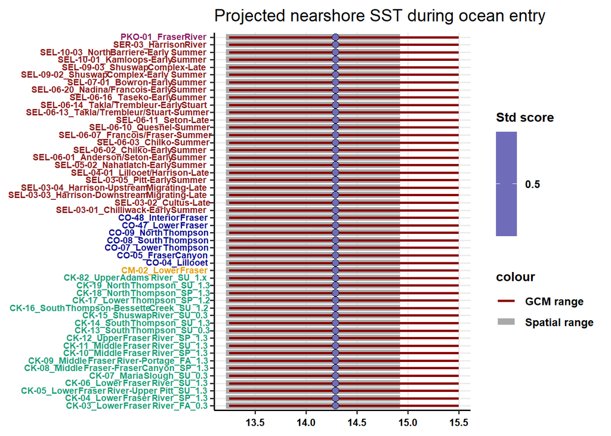

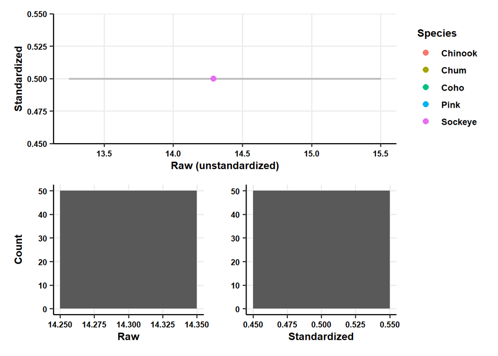

#### 85

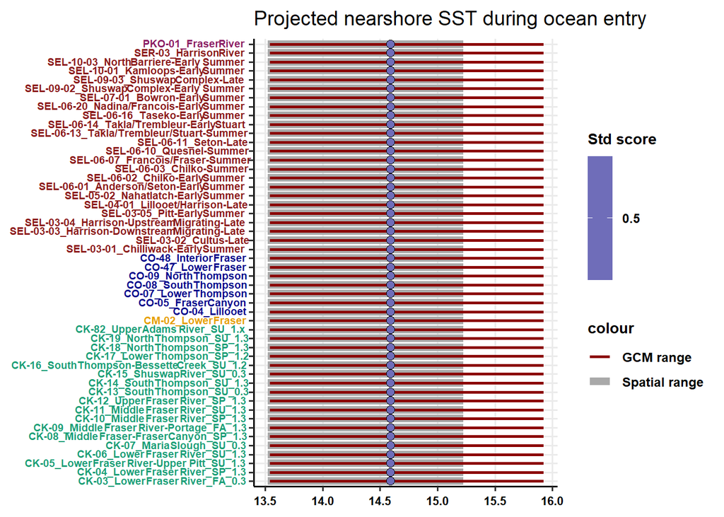

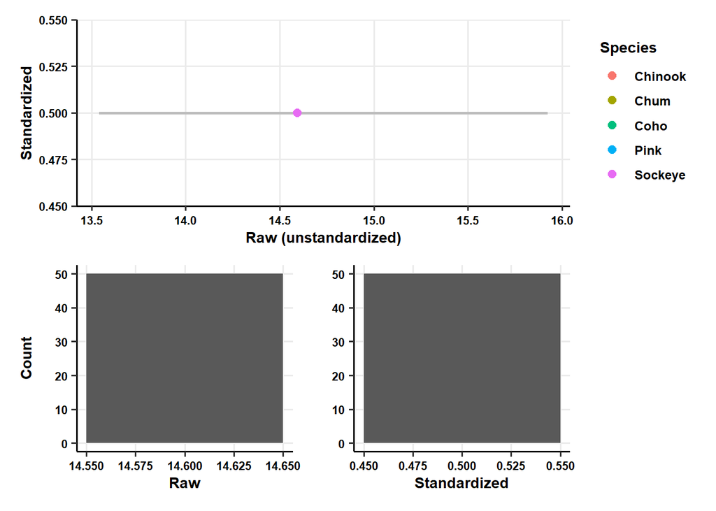

### Rate of change in sea surface temperature near ocean entry

#### 45

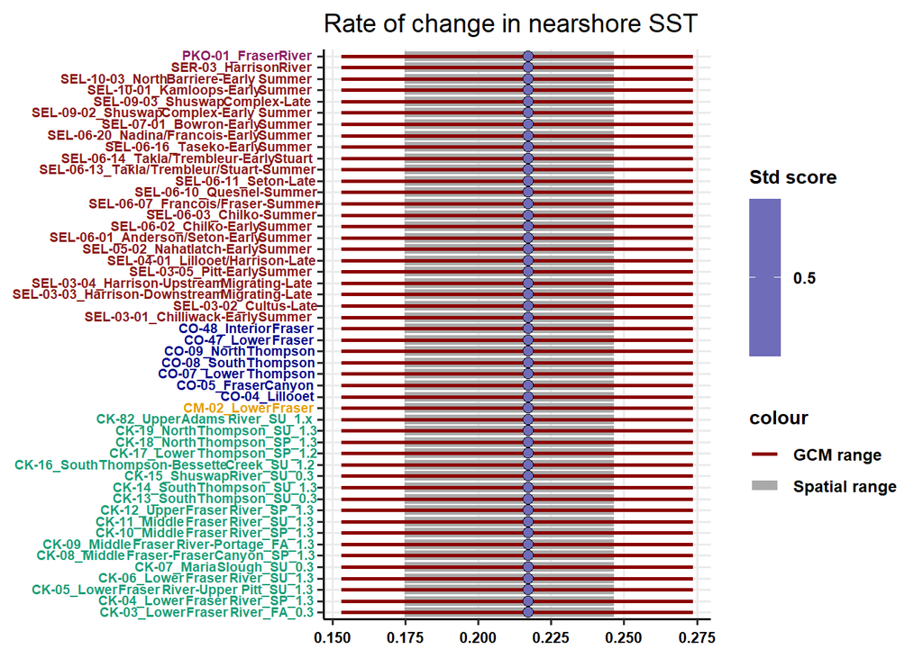

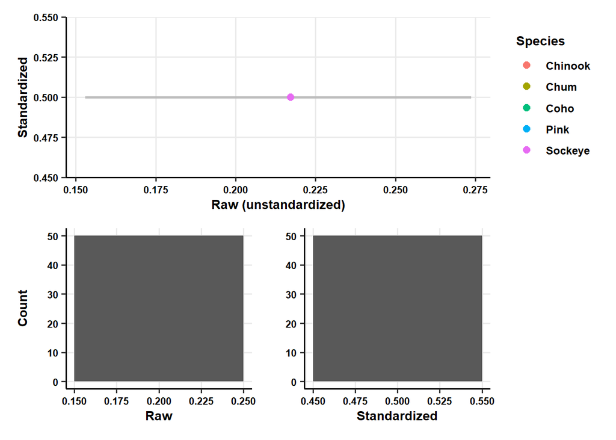

#### 85

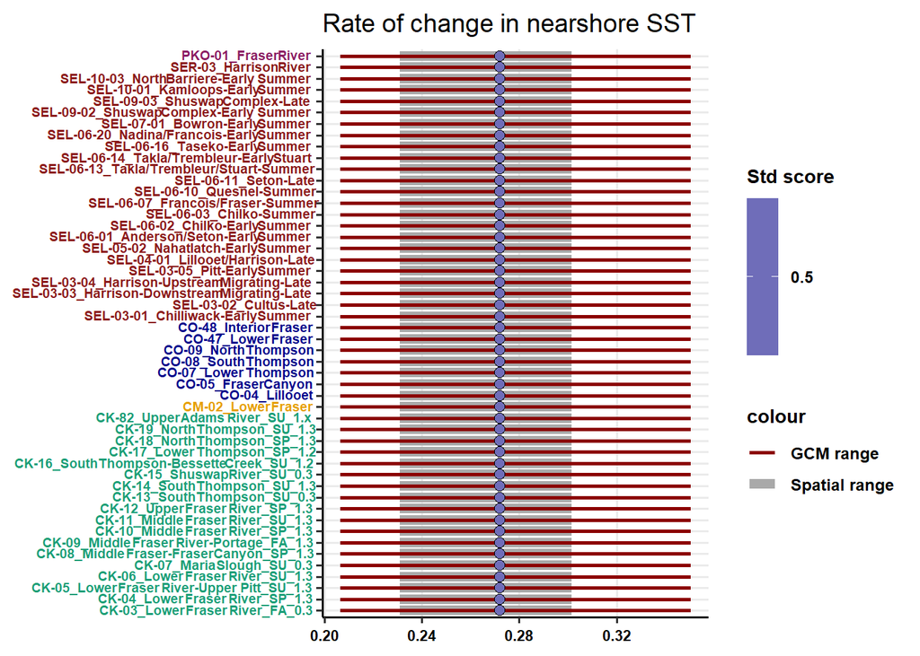

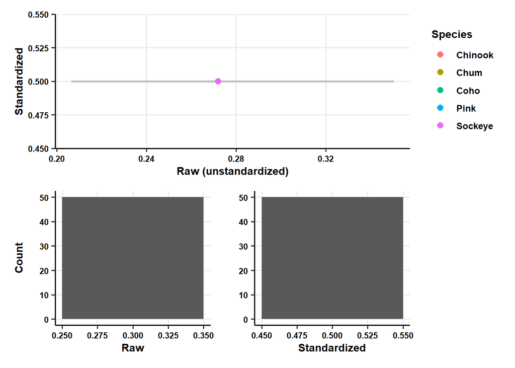

## Genetic Indicators

Genetic indicators to be added: heterozygosity and genomic offset.

# References

CSAS. 2024a. “Geospatial Indicators and Metrics for Threats to Fish Habitat in the Fraser River Basin with Thompson-Nicola as a Case Study.”

———. 2024b. “Rapid Status Approximations for Pacific Salmon Derived from Integrated Expert Assessments Under Fisheries and Oceans Canada Wild Salmon Policy” 004.

Macdonald, B., and S.C.H Grant. 2023. “State of Canadian Pacific Salmon: Considerations for Pacific Salmon Management in a Changing Climate,” 27 p.

Murray, Cathryn Clarke, Noreen E Kelly, Jocelyn C Nelson, Grace E.P. Murphy, and Selina Agbayani. 2024. *Cumulative Impact Mapping and Vulnerability of Canadian Marine Ecosystems to Anthropogenic Activities and Stressors*. Ottawa ON: Canadian Science Advisory Secretariat (CSAS).

Peña, M. Angelica, and Isaac Fine. 2024. “Future Physical and Biogeochemical Ocean Conditions Under Climate Change Along the British Columbia Continental Margin.” *Atmosphere-Ocean* 62 (1): 2–23. https://doi.org/10.1080/07055900.2023.2239186.

Urban, M. C., G. Bocedi, A. P. Hendry, J.-B. Mihoub, G. Pe’er, A. Singer, J. R. Bridle, et al. 2016. “Improving the Forecast for Biodiversity Under Climate Change.” *Science* 353 (6304): aad8466. https://doi.org/10.1126/science.aad8466.

Weller, J. Daniel, R. D. Moore, and Josephine C. Iacarella. 2024. “Stream Thermalscape Scenarios for British Columbia, Canada.” *Canadian Water Resources Journal* 49 (2): 233–52. https://doi.org/10.1080/07011784.2023.2267028.

Wilson, Samantha M., and Stephanie J. Peacock. 2025. “Freshwater Life-Cycle Timing of Pacific Salmon and Steelhead ( *Oncorhynchus* Spp.) in Canada.” *Canadian Journal of Fisheries and Aquatic Sciences* 82 (January): 1–17. https://doi.org/10.1139/cjfas-2024-0213.